# Billboard Charts Data

Adrian Varallyay

2022-04-20

### 1. Top Songs

Interactive datatable with the Top 20 songs (ranked by total weeks on the billboard Top 100) along with their artists, their peak billboard position, and the total weeks they were on the Billboard Top 100. Year range is selected with slider, and user can utilize datatable search and filtering functions.

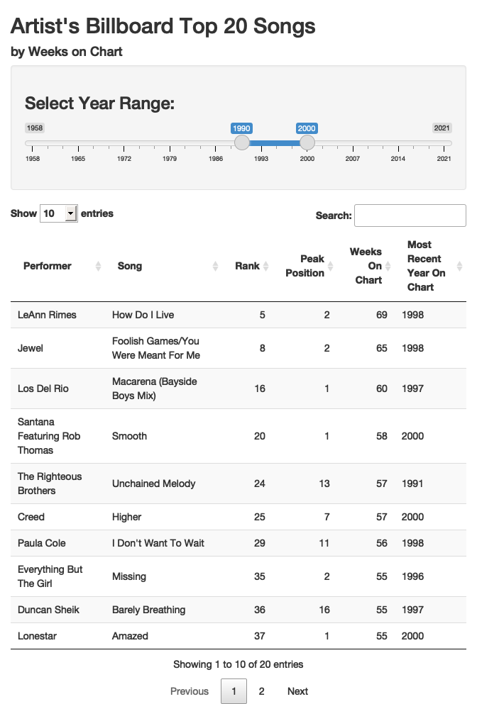

### 2. Top Artists

Full text search bar to select artist to show a visualization of the billboard ranking of all songs of the artist over time. Chart position is situated on the y-axis and date on the x. The slider is used to select the number of songs to be displayed so as to allow user control of plot clutteredness/clarity. Each song for each artist were arbitrarily numbered so as to be able to input for “which songs”.

[figure not shown]

### 3. Audio Features

Multiple selection full text genre search bar, slider date range, plotly scatter plot, Full text search bar to select artist, and “Top 5”, “Top 10”, “Top 20” radio buttons. Spotify track popularity (higher value = higher number) by instrumentalness (logged).

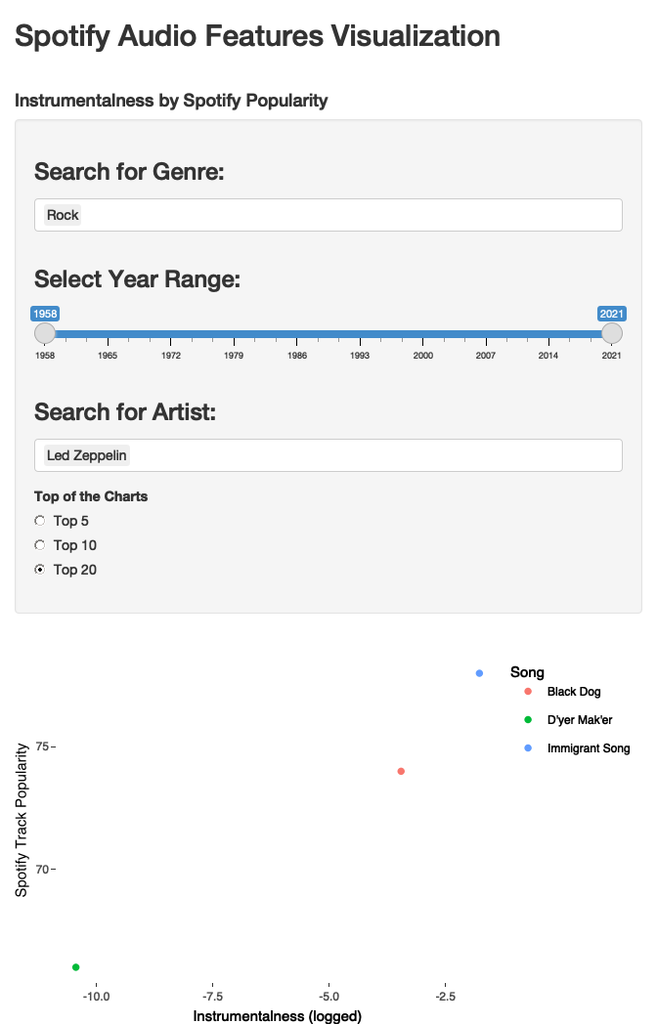